# ExperimentsVCALab

Andrea Ovalle

2/7/2017

Probability ( y axis) that in each trial (x axis) there is a sequence.

EXPERIMENT 1A - Dual target 1-step and 4-step color separations - Split- target cost; similarity of targets decreases, fixations to dissimilar distractors increases. ( STROUD DISSERTATIONS EXP 1A)

```r
data10 <- read.csv("~/Dropbox/VCA LAB/1a  .Means.TargetPresent.csv")

Data10 <- data10[,-(0:1)] # Substracts columns from the data frame

colnames(Data10) = c("03","04","05","06","07","08","09","10","11","12","13","14","15","16","17","18") # adds labels to columns

df4.9 <- gather(Data10, Length, Prob)%>%na.omit() # arranges data into a long format.

df5.9 <- transform(df4.9, Sequence=ave(seq_along(Length),Length, FUN=seq_along)) ## Creates a sequence that runs along the lenght of the fixation.

### Adds counts of the trials

df1.8 <- data.frame(x=c(0:18)) ## adds symbols to each data point for each trial.


my_plot10 <- ggplot(df5.9, aes(x = Sequence , y = Prob))+
  geom_line(aes(group = df5.9$Length, color = Length))+
  geom_point(aes(alpha = 0.03))
```

```r
data11 <- read.csv("~/Dropbox/VCA LAB/1a  .Means.TargetAbsent.csv")


Data11 <- data11[,-(0:1)]

colnames(Data11) = c("03","04","05","06","07","08","09","10","11","12","13","14","15","16","17","18")

df5.1 <- gather(Data11, length, Prob)%>%na.omit() # arranges data into a long format.

df6 <- transform(df5.1, Sequence=ave(seq_along(length), length, FUN=seq_along)) ### Adds counts of the trials

df1.9 <- data.frame(x=c(0:17)) ## adds symbols to each data point for each trial.

#df6$length <- as.numeric(as.character(df6$length))

my_plot11 <- ggplot(df6, aes(x = Sequence , y = Prob))+
  geom_line(aes(group = df6$length, color = length))+
  geom_point(aes(alpha = 0.03))
```

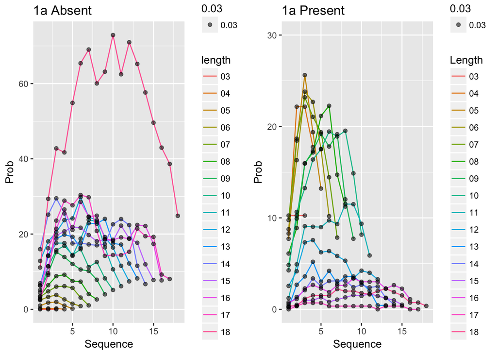

```r
list6 <- list()

for (i in 1:2) {
  my_plot11 <- ggplot(df6, aes(x = Sequence , y = Prob))+
  geom_line(aes(group = df6$length, color = length))+
  geom_point(aes(alpha = 0.03))+ggtitle(label = "1a Absent")
  list6[[1]] <- my_plot11


my_plot10 <- ggplot(df5.9, aes(x = Sequence , y = Prob))+
  geom_line(aes(group = df5.9$Length, color = Length))+
  geom_point(aes(alpha = 0.03))+ggtitle(label = "1a Present")+ylim(0,30)
list6[[2]] <- my_plot10


}

multiplot(plotlist = list6, cols= 2)
```

```r
### (exp. 1b) colour T search

data12 <- read.csv("~/Dropbox/VCA LAB/1b  .Means.TargetPresent.csv")

Data12 <- data12[,-(0:1)]

colnames(Data12) = c("03","04","05","06","07","08","09","10","11","12","13","14","15","16","17","18")

df5.2 <- gather(Data12, length, Prob)%>%na.omit() # arranges data into a long format.

df7 <- transform(df5.2, Sequence=ave(seq_along(length), length, FUN=seq_along)) ### Adds counts of the trials

#df_2 <- data.frame(x=c(0:17)) ## adds symbols to each data point for each trial.



my_plot12 <- ggplot(df7, aes(x = Sequence , y = Prob))+
  geom_line(aes(group = df7$length, color = length))+
  geom_point(aes(alpha = 0.03)) # change labs to upper limits 40 for all of them
```

```r
data13 <- read.csv("~/Dropbox/VCA LAB/1b  .Means.TargetAbsent.csv")

Data13 <- data13[,-(0:1)]

colnames(Data13) = c("03","04","05","06","07","08","09","10","11","12","13","14","15","16","17")

df5.3 <- gather(Data13, length, Prob)%>%na.omit() # arranges data into a long format.

df8 <- transform(df5.3, Sequence=ave(seq_along(length), length, FUN=seq_along)) ### Adds counts of the trials

#df_3 <- data.frame(x=c(0:17)) ## adds symbols to each data point for each trial.



my_plot13 <- ggplot(df8, aes(x = Sequence , y = Prob))+
  geom_line(aes(group = df8$length, color = length))+
  geom_point(aes(alpha = 0.03))
```

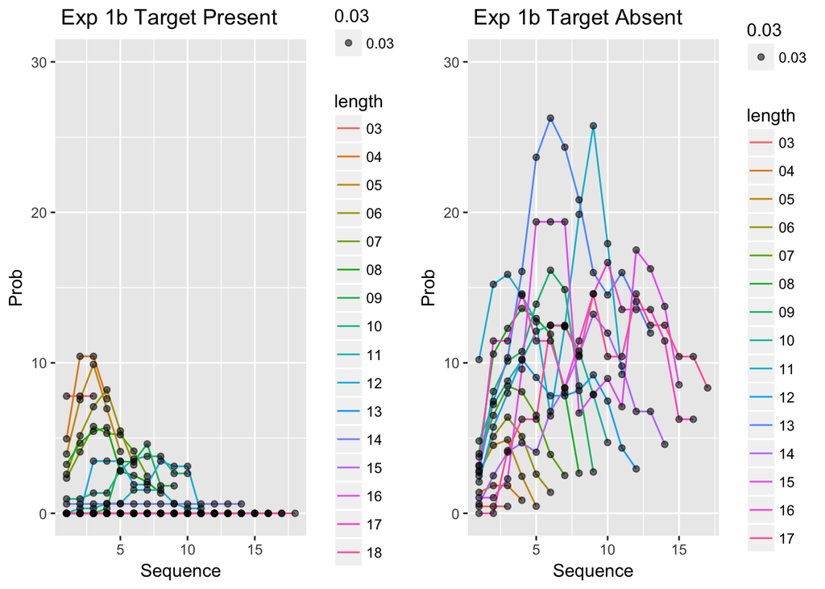

```r
list7<- list()

for (i in 1:2){
 my_plot12 <- ggplot(df7, aes(x = Sequence , y = Prob))+
  geom_line(aes(group = df7$length, color = length))+
  geom_point(aes(alpha = 0.03))+ggtitle(label = " Exp 1b Target Present")+ylim(0,30)
  list7[[1]] <- my_plot12


my_plot13 <- ggplot(df8, aes(x = Sequence , y = Prob))+
  geom_line(aes(group = df8$length, color = length))+
  geom_point(aes(alpha = 0.03))+ggtitle(label = " Exp 1b Target Absent")+ylim(0,30)
  list7[[2]] <- my_plot13
}

multiplot(plotlist = list7, cols =2)
```

Color T search plust WM (orientation)

Orientation bar - WM

Color selectivity was unaffected in the search task. WM accuracy as poor (error rate ~35%)

```r
data <- read.csv("~/Dropbox/VCA LAB/10  .Means.TargetAbsent.csv")

Data <- data[,-(0:1)]

colnames(Data) = c("03","04","05","06","07","08","09","10","11","12","13","14","15","16","17","18")

my_df4 <- gather(Data, length, Prob)%>%na.omit() # arranges data into a long format.

my_df5 <- transform(my_df4, Sequence=ave(seq_along(length), length, FUN=seq_along)) ### Adds counts of the trials

my_plot1 <- ggplot(my_df5, aes(x = Sequence , y = Prob))+
  geom_line(aes(group = my_df5$length, color = length))+
  geom_point(aes(alpha = 0.03))+ggtitle(label = "Exp 10 Target Absent")
```

```r
data2 <- read.csv("~/Dropbox/VCA LAB/10  .Means.TargetPresent.csv")
Data2 <- data2[,-(0:1)]

colnames(Data2) = c("03","04","05","06","07","08","09","10","11","12","13","14","15","16","17", "18")

df4 <- gather(Data2, length, Prob)%>%na.omit() # arranges data into a long format.

df5 <- transform(df4, Sequence=ave(seq_along(length), length, FUN=seq_along)) ### Adds counts of the trials

#df1 <- data.frame(x=c(0:17)) ## adds symbols to each data point for each trial.


my_plot2 <- ggplot(df5, aes(x = Sequence, y = Prob))+
  geom_line(aes(group = df5$length, color = length))+
  geom_point(aes(alpha = 0.03))+ggtitle(label = "Exp 10 Target Present")
```

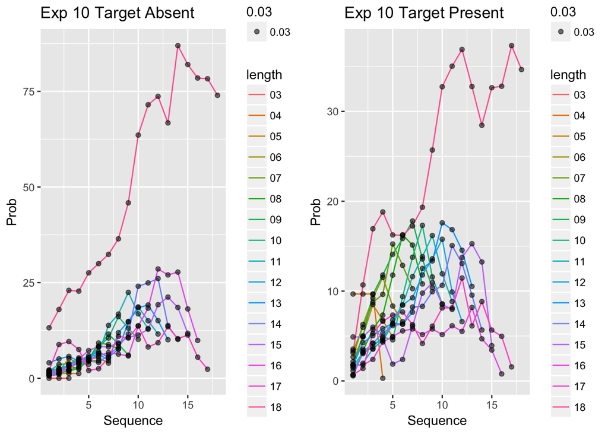

```r
list8 <- list()

for(i in 1:2) {
my_plot1 <- ggplot(my_df5, aes(x = Sequence , y = Prob))+
  geom_line(aes(group = my_df5$length, color = length))+
  geom_point(aes(alpha = 0.03))+ggtitle("Exp 10 Target Absent")
list8[[1]]<- my_plot1

 my_plot2 <- ggplot(df5, aes(x = Sequence, y = Prob))+
  geom_line(aes(group = df5$length, color = length))+
  geom_point(aes(alpha = 0.03))+ggtitle(label = "Exp 10 Target Present")
list8[[2]] <- my_plot2

}

multiplot(plotlist = list8, cols = 2)
```

COLOR T SEARCH PLUS WM ( DOTS )

Spatial dot task. Color selectivity was unaffected. WM accuracy was similar to color patch ( error rate ~ 35%)

```r
data3 <- read.csv("~/Dropbox/VCA LAB/11  .Means.TargetAbsent.csv")

Data3 <- data3[,-(0:1)]

colnames(Data3) = c("03","04","05","06","07","08","09","10","11","12","13","14","15","16","17","18")

df4.2 <- gather(Data3, length, Prob)%>%na.omit() # arranges data into a long format.

df5.2 <- transform(df4.2, Sequence=ave(seq_along(length), length, FUN=seq_along)) ### Adds counts of the trials

#df1.1 <- data.frame(x=c(0:17)) ## adds symbols to each data point for each trial.


my_plot3 <- ggplot(df5.2, aes(x = Sequence , y = Prob))+
  geom_line(aes(group = df5.2$length, color = length))+
  geom_point(aes(alpha = 0.03))+ggtitle(label = "Exp 11 Target Absent")
```

```r
data4 <- read.csv("~/Dropbox/VCA LAB/11  .Means.TargetPresent.csv")

Data4 <- data4[,-(0:1)]

colnames(Data4) = c("03","04","05","06","07","08","09","10","11","12","13","14","15","16","17","18")

df4.3 <- gather(Data4, length, Prob)%>%na.omit() # arranges data into a long format.

df5.3 <- transform(df4.3, Sequence=ave(seq_along(length), length, FUN=seq_along)) ### Adds counts of the trials

#df1.2 <- data.frame(x=c(0:17)) ## adds symbols to each data point for each trial.

my_plot4 <- ggplot(df5.3, aes(x = Sequence , y = Prob))+
  geom_line(aes(group = df5.3$length, color = length))+
  geom_point(aes(alpha = 0.03))+ggtitle(label = "Exp 11 Target Present")
```

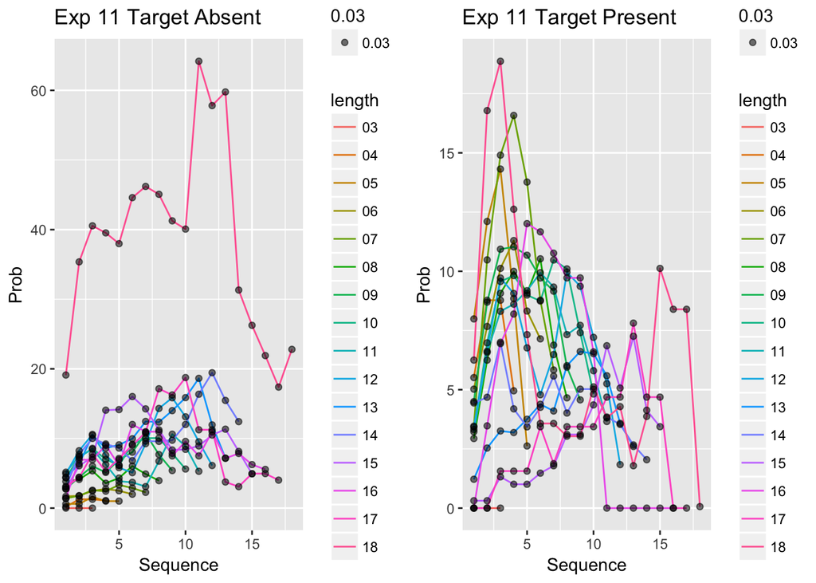

```r
list9 <- list()

for (i in 1:2) {
  my_plot3 <- ggplot(df5.2, aes(x = Sequence , y = Prob))+
  geom_line(aes(group = df5.2$length, color = length))+
  geom_point(aes(alpha = 0.03))+ggtitle(label = "Exp 11 Target Absent")
list9[[1]]<- my_plot3

my_plot4 <- ggplot(df5.3, aes(x = Sequence , y = Prob))+
  geom_line(aes(group = df5.3$length, color = length))+
  geom_point(aes(alpha = 0.03))+ggtitle(label = "Exp 11 Target Present")
list9[[2]] <- my_plot4

}

multiplot(plotlist = list9, cols = 2)
```

COLOR SEARCH AMONG T’s plus WM

Pure color T search with Working memory load.

```r
##Pure Color T Search with WM (exp. 12)    colour search among T's plus WM

data5 <- read.csv("~/Dropbox/VCA LAB/12 .Means.TargetAbsent.csv")

Data5 <- data5[,-(0:1)]

colnames(Data5) = c("03","04","05","06","07","08","09","10","11","12","13","14","15","16","17","18")

df4.4 <- gather(Data5, length, Prob)%>%na.omit() # arranges data into a long format.

df5.4 <- transform(df4.4, Sequence=ave(seq_along(length), length, FUN=seq_along)) ### Adds counts of the trials

my_plot5 <- ggplot(df5.4, aes(x = Sequence , y = Prob))+
  geom_line(aes(group = df5.4$length, color = length))+
  geom_point(aes(alpha = 0.03))+ggtitle(label = "Exp 12 Target Absent")
```

```r
data6 <- read.csv("~/Dropbox/VCA LAB/12 .Means.TargetPresent.csv")

Data6 <- data6[,-(0:1)]

colnames(Data6) = c("03","04","05","06","07","08","09","10","11","12","13","14","15","16","17")

df4.5 <- gather(Data6, length, Prob)%>%na.omit() # arranges data into a long format.

df5.5 <- transform(df4.5, Sequence=ave(seq_along(length), length, FUN=seq_along)) ### Adds counts of the trials

#df1.4 <- data.frame(x=c(0:17)) ## adds symbols to each data point for each trial.



my_plot6 <- ggplot(df5.5, aes(x = Sequence , y = Prob))+
  geom_line(aes(group = df5.5$length, color = length))+
  geom_point(aes(alpha = 0.03))+ggtitle(label = "Exp 12 Target Present")
```

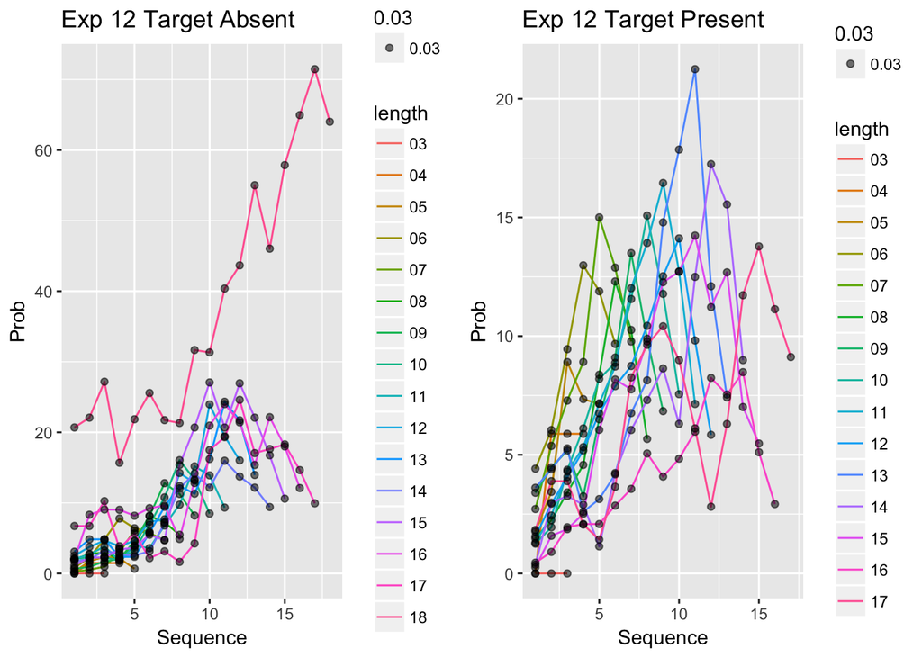

```r
list10 <- list()

for (i in 1:2){
  my_plot5 <- ggplot(df5.4, aes(x = Sequence , y = Prob))+
  geom_line(aes(group = df5.4$length, color = length))+
  geom_point(aes(alpha = 0.03))+ggtitle(label = "Exp 12 Target Absent")
  list10[[1]]<-my_plot5

  my_plot6 <- ggplot(df5.5, aes(x = Sequence , y = Prob))+
  geom_line(aes(group = df5.5$length, color = length))+
  geom_point(aes(alpha = 0.03))+ggtitle(label = "Exp 12 Target Present")
  list10[[2]]<- my_plot6
}

multiplot(plotlist = list10, cols = 2)
```

Color Search among T’s

Single target pure color search similar to Exp 12 but not W, and with a new set of stimuli

```r
##Pure Color T Search No WM (exp. 16)    colour search among T's


data7 <- read.csv("~/Dropbox/VCA LAB/16 .Means.TargetAbsent.csv")

Data7 <- data7[,-(0:1)]


colnames(Data7) = c("03","04","05","06","07","08","09","10","11","12","13","14","15","16","17","18")


df4.6 <- gather(Data7, length, Prob)%>%na.omit() # arranges data into a long format.

df5.6 <- transform(df4.6, Sequence=ave(seq_along(length), length, FUN=seq_along)) ### Adds counts of the trials

#df1.5 <- data.frame(x=c(0:17)) ## adds symbols to each data point for each trial.



my_plot7 <- ggplot(df5.6, aes(x = Sequence , y = Prob))+
  geom_line(aes(group = df5.6$length, color = length))+
  geom_point(aes(alpha = 0.03))+ggtitle(label = "Exp 16 Absent")
```

```r
data7.1 <- read.csv("~/Dropbox/VCA LAB/16 .Means.TargetPresent.csv")

Data7.1 <- data7.1[,-(0:1)]

colnames(Data7.1) =c("03","04","05","06","07","08","09","10","11","12","13","14","15","16","17","18")

df4.6.1 <- gather(Data7.1, length, Prob)%>%na.omit() # arranges data into a long format.

df5.6.1 <- transform(df4.6.1, Sequence=ave(seq_along(length), length, FUN=seq_along)) ### Adds counts of the trials

#df1.5.1 <- data.frame(x=c(0:17)) ## adds symbols to each data point for each trial.



my_plot7.1 <- ggplot(df5.6.1, aes(x = Sequence , y = Prob))+
  geom_line(aes(group = df5.6.1$length, color = length))+
  geom_point(aes(alpha = 0.03))+ggtitle(label = "Exp 16 Present")
```

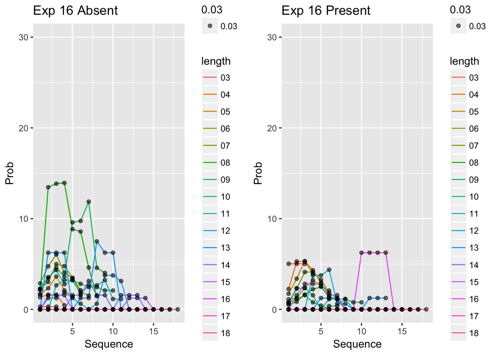

```r
List11 <- list()

for (i in 1:2){
  my_plot7 <- ggplot(df5.6, aes(x = Sequence , y = Prob))+
  geom_line(aes(group = df5.6$length, color = length))+
  geom_point(aes(alpha = 0.03))+ggtitle(label = "Exp 16 Absent")+ylim(0,30)
  List11[[1]]<- my_plot7

 my_plot7.1 <- ggplot(df5.6.1, aes(x = Sequence , y = Prob))+
  geom_line(aes(group = df5.6.1$length, color = length))+
  geom_point(aes(alpha = 0.03))+ggtitle(label = "Exp 16 Present")+ylim(0,30)
 List11[[2]]<- my_plot7.1
}

multiplot(plotlist = List11, cols=2)
```

Dual Target Pure Color T search Two color search among T’s Dual target color search with only T’s (4step)

```r
###Dual Target Pure Color Search (4-step) (exp. 18)    dual colour search among T's

data8 <- read.csv("~/Dropbox/VCA LAB/18 .Means.TargetPresent (1).csv")

Data8 <- data8[,-(0:1)]

colnames(Data8) = c("03","04","05","06","07","08","09","10","11","12","13","14","15","16","17","18")

df4.7 <- gather(Data8, length, Prob)%>%na.omit() # arranges data into a long format.

df5.7 <- transform(df4.7, Sequence=ave(seq_along(length),length, FUN=seq_along)) ### Adds counts of the trials

#df1.6 <- data.frame(x=c(0:17)) ## adds symbols to each data point for each trial.

my_plot8 <- ggplot(df5.7, aes(x = Sequence , y = Prob))+
  geom_line(aes(group = df5.7$length, color = length))+
  geom_point(aes(alpha = 0.03))+ggtitle(label = "Exp 18 Target Present")
```

```r
data9 <- read.csv("~/Dropbox/VCA LAB/18 .Means.TargetAbsent.csv")

Data9 <- data9[,-(0:1)]

colnames(Data9) = c("03","04","06","07","08","09","10","11","12","13","14","15","16","17","18","19")

df4.8 <- gather(Data9, length, Prob)%>%na.omit() # arranges data into a long format.

df5.8 <- transform(df4.8, Sequence=ave(seq_along(length),length, FUN=seq_along)) ### Adds counts of the trials

#df1.7 <- data.frame(x=c(0:17)) ## adds symbols to each data point for each trial.



my_plot9 <- ggplot(df5.8, aes(x = Sequence , y = Prob))+
  geom_line(aes(group = df5.8$length, color = length))+
  geom_point(aes(alpha = 0.03))+ggtitle(label = "Exp 18 Target Absent")
```

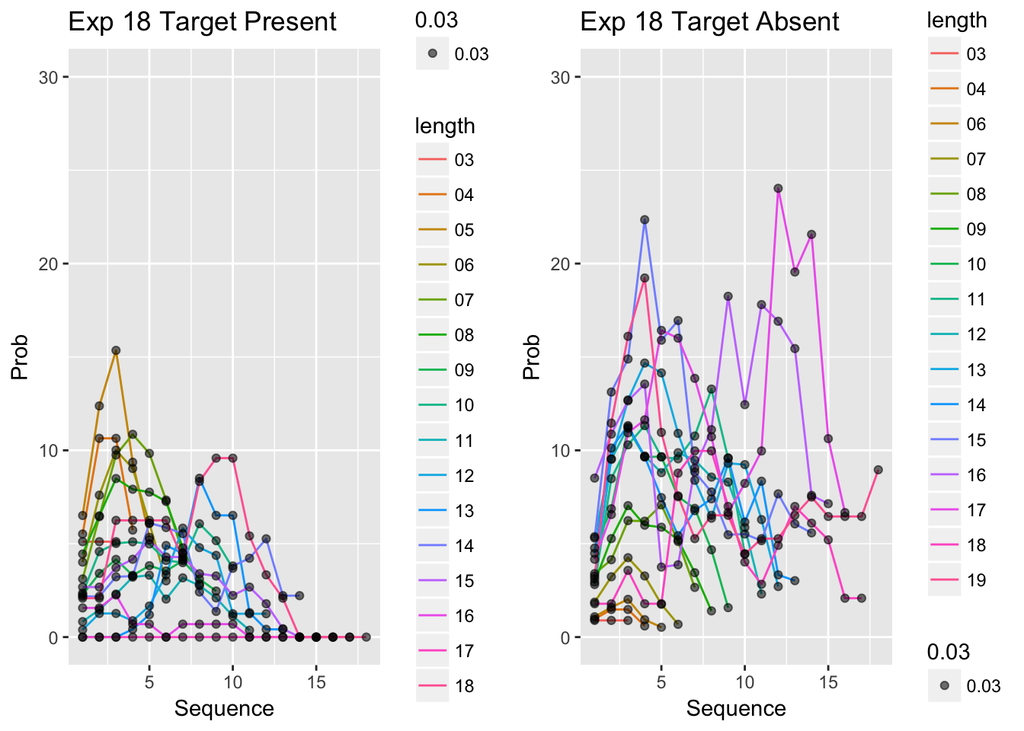

```r
list12 <- list()
for (i in 1:2){
  my_plot8 <- ggplot(df5.7, aes(x = Sequence , y = Prob))+
  geom_line(aes(group = df5.7$length, color = length))+
  geom_point(aes(alpha = 0.03))+ggtitle(label = "Exp 18 Target Present")+ylim(0,30)
  list12[[1]]<- my_plot8

my_plot9 <- ggplot(df5.8, aes(x = Sequence , y = Prob))+
  geom_line(aes(group = df5.8$length, color = length))+
  geom_point(aes(alpha = 0.03))+ggtitle(label = "Exp 18 Target Absent")+ylim(0,30)
  list12[[2]]<- my_plot9

}
 multiplot(plotlist = list12, cols = 2)
```

COLOR T SEARCH PLUS WORKING MEMORY

- Single target search for color with color patch working memory load
- Color selectivity with the WM load was disrupted across al distractor colors. The identity of the WM load color had no specific effect on the search fixation patterns. WM accuracy was okay for exact color ( ~ 35% error rate) but excellent for 1-2 steps from color (~8%)

```r
data14 <- read.csv("~/Dropbox/VCA LAB/7  .Means.TargetPresent.csv")

Data14 <- data14[,-(0:1)]

colnames(Data14) = c("03","04","05","06","07","08","09","10","11","12","13","14","15","16","17","18")

df5.4 <- gather(Data14, length, Prob)%>%na.omit() # arranges data into a long format.

df9 <- transform(df5.4, Sequence=ave(seq_along(length), length, FUN=seq_along)) ### Adds counts of the trials

#df_4 <- data.frame(x=c(0:17)) ## adds symbols to each data point for each trial.



my_plot14 <- ggplot(df9, aes(x = Sequence , y = Prob))+
  geom_line(aes(group = df9$length, color = length))+
  geom_point(aes(alpha = 0.03))+ggtitle(label = "Exp 7 Target Present")+ylim(0,30)
```

```r
data15 <- read.csv("~/Dropbox/VCA LAB/7  .Means.TargetAbsent.csv")

Data15 <- data15[,-(0:1)]

colnames(Data15) = c("03","04","05","06","07","08","09","10","11","12","13","14","15","16","17","18")

df5.5 <- gather(Data15, length, Prob)%>%na.omit() # arranges data into a long format.

df10 <- transform(df5.5, Sequence=ave(seq_along(length),length, FUN=seq_along)) ### Adds counts of the trials

#df_5 <- data.frame(x=c(0:17)) ## adds symbols to each data point for each trial.



my_plot15 <- ggplot(df10, aes(x = Sequence , y = Prob))+
  geom_line(aes(group = df10$length, color = length))+
  geom_point(aes(alpha = 0.03))+ggtitle(label = "Exp 7 Target Absent")
```

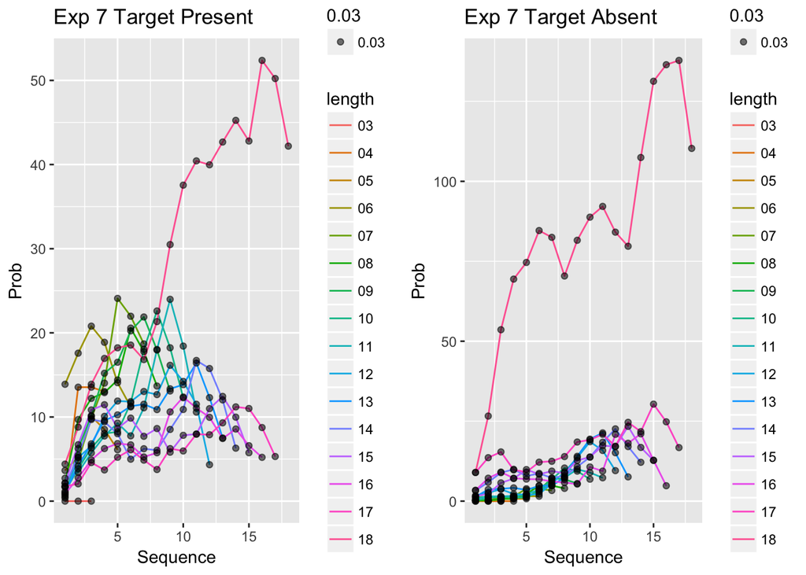

```r
list13 <- list()

for (i in 1:2){
  my_plot14 <- ggplot(df9, aes(x = Sequence , y = Prob))+
  geom_line(aes(group = df9$length, color = length))+
  geom_point(aes(alpha = 0.03))+ggtitle(label = "Exp 7 Target Present")
  list13[[1]]<- my_plot14

  my_plot15 <- ggplot(df10, aes(x = Sequence , y = Prob))+
  geom_line(aes(group = df10$length, color = length))+
  geom_point(aes(alpha = 0.03))+ggtitle(label = "Exp 7 Target Absent")
  list13[[2]]<- my_plot15

}

multiplot(plotlist = list13, cols = 2)
```

COLOR T SEARCH PLUS WORKING MEMORY

Single target search for color with WM load.

- Color selectivity was slightly affected across all distractor colors. Working memory accuracy was very good (~10% error rate)

```r
data16 <- read.csv("~/Dropbox/VCA LAB/8  .Means.TargetPresent.csv")

Data16 <- data16[,-(0:1)]

colnames(Data16) = c("03","04","05","06","07","08","09","10","11","12","13","14","15","16","17")

df5.6 <- gather(Data16, length, Prob)%>%na.omit() # arranges data into a long format.

df11 <- transform(df5.6, Sequence=ave(seq_along(length),length, FUN=seq_along)) ### Adds counts of the trials

#df_6 <- data.frame(x=c(0:17)) ## adds symbols to each data point for each trial.



my_plot16 <- ggplot(df11, aes(x = Sequence , y = Prob))+
  geom_line(aes(group = df11$length, color = length))+
  geom_point(aes(alpha = 0.03))+ggtitle(label = "Exp 8 Target Present")
```

```r
data17 <- read.csv("~/Dropbox/VCA LAB/8  .Means.TargetAbsent.csv")


Data17 <- data17[,-(0:1)]

colnames(Data17) = c("03","04","05","06","07","08","09","10","11","12","13","14","15","16","17")

df5.7 <- gather(Data17, length, Prob)%>%na.omit() # arranges data into a long format.

df12 <- transform(df5.7, Sequence=ave(seq_along(length), length, FUN=seq_along)) ### Adds counts of the trials

##df_7 <- data.frame(x=c(0:17)) ## adds symbols to each data point for each trial.



my_plot17 <- ggplot(df12, aes(x = Sequence , y =Prob))+
  geom_line(aes(group = df12$length, color = length))+
  geom_point(aes(alpha = 0.03))+ggtitle(label = "")
```

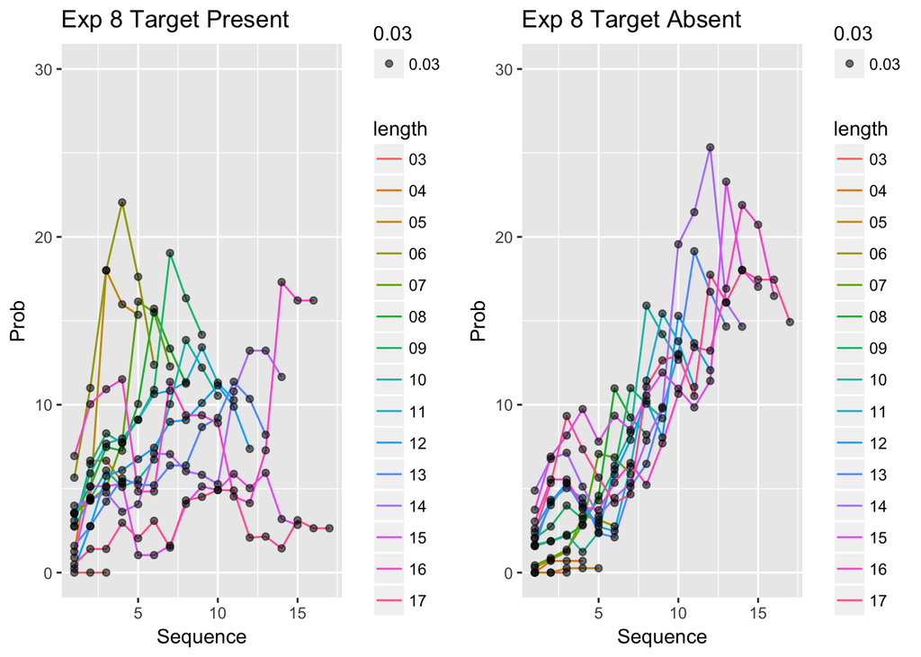

```r
list14 <- list()

for (i in 1:2){
  my_plot16 <- ggplot(df11, aes(x = Sequence , y = Prob))+
  geom_line(aes(group = df11$length, color = length))+
  geom_point(aes(alpha = 0.03))+ggtitle(label = "Exp 8 Target Present")+ylim(0,30)
  list14[[1]]<- my_plot16


  my_plot17 <- ggplot(df12, aes(x = Sequence , y =Prob))+
  geom_line(aes(group = df12$length, color = length))+
  geom_point(aes(alpha = 0.03))+ggtitle(label = "Exp 8 Target Absent")+ylim(0,30)
  list14[[2]]<- my_plot17

  }


multiplot(plotlist = list14, cols =2)
```